# Tidying_data

ayandabuso

2025-02-20

Tidying insect data using tidyverse!

This data is already in my working directiory which i just saved directly to after creating it.Fistly, we load necessary libraries to read in data.

```r
#loading necessary libraries
library(tidyverse)
#we need to also add package to read an excel file
# Read the CSV file
insect_data <- read_csv("insects_data.csv")
```

Now we are going to check our data and look for missing values

```r
# check for missing values
sum(is.na(insect_data))
```

```
## [1] 0
```

I would like my data to to use proper colomn names for easier understanding of what they mean.

```r
# Convert data types
insect_data <- insect_data %>%
  mutate(
    pitfall_id = as.factor(pitfall_id),
    site_name = as.factor(site),
    collection_date = as.Date(date),
    insect_taxa = as.factor(taxa),
    count = as.numeric(count)  # Ensure count is numeric
  )

# Check structure
glimpse(insect_data)
```

```
## Rows: 18
## Columns: 8
## $ pitfall_id      <fct> 1, 1, 1, 2, 2, 2, 3, 3, 3, 4, 4, 4, 5, 5, 5, 6, 6, 6
## $ site            <chr> "site_A", "site_A", "site_A", "site_B", "site_B", "sit…
## $ date            <chr> "01-02-2025", "01-02-2025", "01-02-2025", "01-02-2025"…
## $ taxa            <chr> "ant", "bettle", "grasshopper", "butterfly", "ant", "b…
## $ count           <dbl> 6, 3, 2, 7, 4, 1, 6, 2, 1, 7, 10, 5, 4, 6, 4, 6, 2, 2
## $ site_name       <fct> site_A, site_A, site_A, site_B, site_B, site_B, site_C…
## $ collection_date <date> 0001-02-20, 0001-02-20, 0001-02-20, 0001-02-20, 0001-0…
## $ insect_taxa     <fct> ant, bettle, grasshopper, butterfly, ant, bettle, fly,…
```

We are interested in knowing the total abundance of each insect group recorded in the”taxa” colomn which is iportant in addressing the question, the code below answeres that.

```r
taxa_abundance <- insect_data %>%
  group_by(insect_taxa) %>%
  summarise(total_abundance = sum(count, na.rm = TRUE)) %>%
  arrange(desc(total_abundance))

# View summarized table
print(taxa_abundance)
```

```
## # A tibble: 6 × 2
##   insect_taxa total_abundance
##   <fct>                 <dbl>
## 1 ant                      23
## 2 butterfly                18
## 3 thrip                    12
## 4 bettle                   10
## 5 grasshopper               9
## 6 fly                       6
```

lets visualise these abundance data!

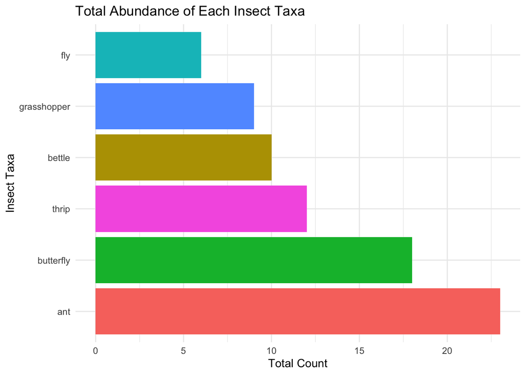

```r
#first we need to load ggplot2 for this visualization.
library(ggplot2)
# Create a bar plot of insect abundance
ggplot(taxa_abundance, aes(x = reorder(insect_taxa, -total_abundance), y = total_abundance, fill = insect_taxa)) +
  geom_bar(stat = "identity") +
  labs(title = "Total Abundance of Each Insect Taxa",
       x = "Insect Taxa",
       y = "Total Count") +
  theme_minimal() +
  theme(legend.position = "none") +
  coord_flip()
```

Beatiful! Now that we have gotten some knowledge about the abundance of the insect groups for example noting that the ants are most abundant and the flies are the least, but this barplot also helps us easily answer the second question of interest which is the species richness! we can tell that there are six different groups of insects found; flies,grasshoppers, bettles, thrips,butterflies and ants.

We can also visualize insect abundance between sites

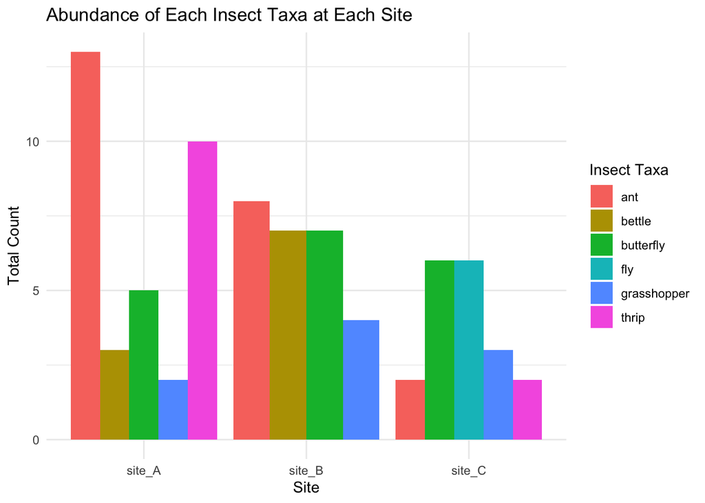

```r
# Summarize abundance per insect taxa at each site
taxa_site_abundance <- insect_data %>%
  group_by(site_name, insect_taxa) %>%
  summarise(total_abundance = sum(count, na.rm = TRUE), .groups = "drop")

# Generate grouped bar plot
ggplot(taxa_site_abundance, aes(x = site_name, y = total_abundance, fill = insect_taxa)) +
  geom_bar(stat = "identity", position = "dodge") +
  labs(title = "Abundance of Each Insect Taxa at Each Site",
       x = "Site",
       y = "Total Count",
       fill = "Insect Taxa") +
  theme_minimal()
```

We can compare species richness between sites:

```r
# Calculate species richness by counting unique taxa per site
site_species_richness <- insect_data %>%
  group_by(site_name) %>%
  summarise(species_richness = n_distinct(insect_taxa)) %>%
  arrange(desc(species_richness))

# View results
print(site_species_richness)
```

```
## # A tibble: 3 × 2
##   site_name species_richness
##   <fct>                <int>
## 1 site_A                   5
## 2 site_C                   5
## 3 site_B                   4
```

The overall species_richness:

```r
# Calculate the total number of unique insect taxa across all sites
overall_species_richness <- insect_data %>%
  summarise(total_unique_taxa = n_distinct(insect_taxa))

#Print result
print(overall_species_richness)
```

```
## # A tibble: 1 × 1
##   total_unique_taxa
##               <int>
## 1                 6
```

```r
insect_data
```

```
## # A tibble: 18 × 8
##    pitfall_id site   date      taxa  count site_name collection_date insect_taxa
##    <fct>      <chr>  <chr>     <chr> <dbl> <fct>     <date>          <fct>
##  1 1          site_A 01-02-20… ant       6 site_A    0001-02-20      ant
##  2 1          site_A 01-02-20… bett…     3 site_A    0001-02-20      bettle
##  3 1          site_A 01-02-20… gras…     2 site_A    0001-02-20      grasshopper
##  4 2          site_B 01-02-20… butt…     7 site_B    0001-02-20      butterfly
##  5 2          site_B 01-02-20… ant       4 site_B    0001-02-20      ant
##  6 2          site_B 01-02-20… bett…     1 site_B    0001-02-20      bettle
##  7 3          site_C 02-02-20… fly       6 site_C    0002-02-20      fly
##  8 3          site_C 02-02-20… thrip     2 site_C    0002-02-20      thrip
##  9 3          site_C 02-02-20… gras…     1 site_C    0002-02-20      grasshopper
## 10 4          site_A 02-02-20… ant       7 site_A    0002-02-20      ant
## 11 4          site_A 02-02-20… thrip    10 site_A    0002-02-20      thrip
## 12 4          site_A 02-02-20… butt…     5 site_A    0002-02-20      butterfly
## 13 5          site_B 03-02-20… gras…     4 site_B    0003-02-20      grasshopper
## 14 5          site_B 03-02-20… bett…     6 site_B    0003-02-20      bettle
## 15 5          site_B 03-02-20… ant       4 site_B    0003-02-20      ant
## 16 6          site_C 03-02-20… butt…     6 site_C    0003-02-20      butterfly
## 17 6          site_C 03-02-20… ant       2 site_C    0003-02-20      ant
## 18 6          site_C 02-02-20… gras…     2 site_C    0002-02-20      grasshopper
```